# Figure1_20220224

# Figure1

required libraries

```
## Setting options('download.file.method.GEOquery'='auto')
```

```
## Setting options('GEOquery.inmemory.gpl'=FALSE)
```

Load data and build SEs

```r
STR2d <- readRDS("../data/STR2.dHC.SE.rds")
STR2v <- readRDS("../data/STR2.vHC.SE.rds")
STR3 <- readRDS("../data/STR3.vHC.SE.rds")

STR2 <- cbind(STR2d,STR2v)
STR2$SampleNumber <- NULL
STR <- cbind(STR2,STR3)
STR$Condition2[STR$Condition2 == "Saline-Ctrl"] <- "PBS-Control"
STR$Condition2[STR$Condition2 == "Saline-Stress"] <- "PBS-Stress"
STR$Condition2 <- droplevels(STR$Condition2)
STR$Condition[STR$Condition == "Control"] <- "Homecage"
STR <- dosvacor(STR, form = ~Condition2 + Experiment + Region, form0 = ~Experiment + Region)
```

```
##   Note: levels of factors in the design contain characters other than
##   letters, numbers, '_' and '.'. It is recommended (but not required) to use
##   only letters, numbers, and delimiters '_' or '.', as these are safe characters
##   for column names in R. [This is a message, not a warning or an error]
```

```
##   Note: levels of factors in the design contain characters other than
##   letters, numbers, '_' and '.'. It is recommended (but not required) to use
##   only letters, numbers, and delimiters '_' or '.', as these are safe characters
##   for column names in R. [This is a message, not a warning or an error]
```

```
## Number of significant surrogate variables is:  10
## Iteration (out of 5 ):1  2  3  4  5
```

```r
STR2 <- dosvacor(STR2, form = ~Condition + Injection, form0 = ~Region)
```

```
## Number of significant surrogate variables is:  5
## Iteration (out of 5 ):1  2  3  4  5
```

```r
STR2 <- STR2[,order(STR2$Region,STR2$Condition2)]
STR3 <- STR3[,order(STR3$Injection,STR3$Condition,STR3$Sex)]


Results <- list()

mincount <- 30
```

## Figure 1: STR2 Analysis of dHC and vHC

```r
#dHC
STR2d$Condition2 <- droplevels(STR2d$Condition2)
STR2d <- dosvacor(STR2d,form = ~Condition2)
```

[output not shown]

```
## Number of significant surrogate variables is:  5
## Iteration (out of 5 ):1  2  3  4  5
```

```r
STR2d <- STR2d[,order(STR2d$Injection,STR2d$Condition)]

STR2d_design <- model.matrix(~STR2d$Condition2 + STR2d$SV1 + STR2d$SV2 + STR2d$SV3 + STR2d$SV4 + STR2d$SV5)

y <- DGEList(counts=assays(STR2d)$counts)
y <- calcNormFactors(y)
y <- estimateDisp(y,STR2d_design)
#filter out genes that are low expressed
y <- y[filterByExpr(y, STR2d_design, min.count = mincount),]
STR2d_fit <- glmQLFit(y,STR2d_design)

#vHC
STR2v$Condition2 <- droplevels(STR2v$Condition2)
STR2v <- dosvacor(STR2v,form = ~Condition2)
```

[output not shown]

```
## Number of significant surrogate variables is:  3
## Iteration (out of 5 ):1  2  3  4  5
```

```r
STR2v <- STR2v[,order(STR2v$Injection,STR2v$Condition)]

STR2v_design <- model.matrix(~STR2v$Condition2 + STR2v$SV1 + STR2v$SV2 + STR2v$SV3)

y <- DGEList(counts=assays(STR2v)$counts)
y <- calcNormFactors(y)
y <- estimateDisp(y,STR2v_design)
#filter out genes that are low expressed
y <- y[filterByExpr(y, STR2v_design, min.count = mincount),]
STR2v_fit <- glmQLFit(y,STR2v_design)
```

### Stress responsive genes (HeatMap Fig1B)

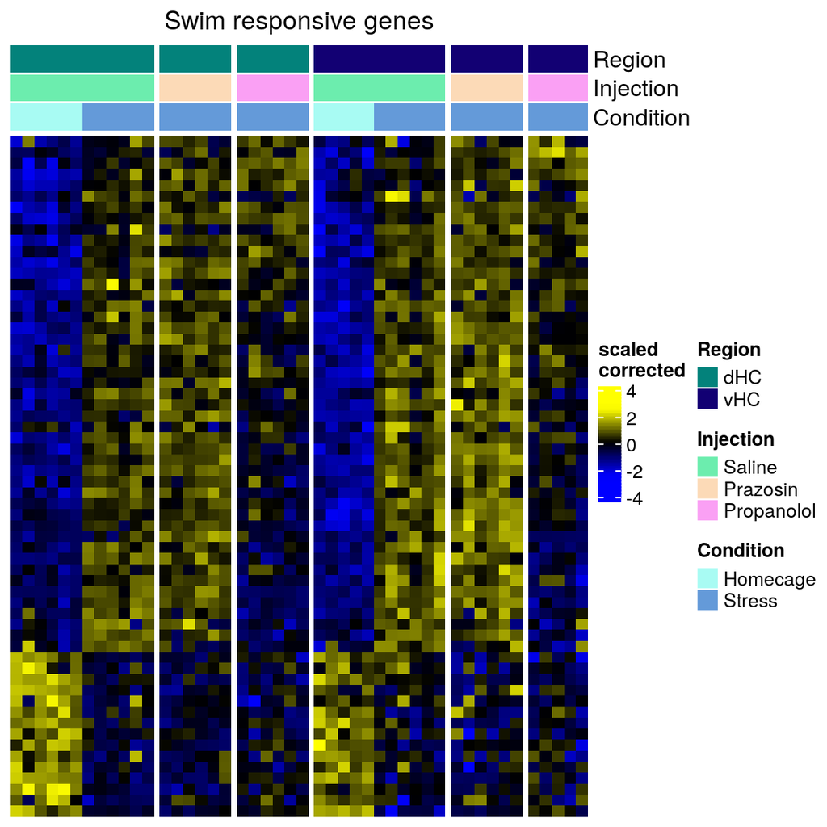

```r
Results[["STR2d_FullModel"]] <- glmQLFTest(STR2d_fit, colnames(STR2d_design)[2:5])
Results[["STR2v_FullModel"]] <- glmQLFTest(STR2v_fit, colnames(STR2v_design)[2:5])
Results[["STR2d_StressEffect"]] <- glmQLFTest(STR2d_fit, contrast = c(0,1,1,0,0,0,0,0,0,0))
Results[["STR2v_StressEffect"]] <- glmQLFTest(STR2v_fit, contrast = c(0,1,1,0,0,0,0,0))
Results[["STR2v_CtrlvsSwim"]] <- glmQLFTest(STR2v_fit, contrast = c(0,1,0,0,0,0,0,0))
Results[["STR2d_CtrlvsSwim"]] <- glmQLFTest(STR2d_fit, contrast = c(0,1,0,0,0,0,0,0,0,0))



#Genes that are significant in either dHC or vHC
sig_str <- union(rownames(topTags(Results[["STR2d_StressEffect"]], p = 0.05, n = Inf)),rownames(topTags(Results[["STR2v_StressEffect"]], p = 0.05, n = Inf)))
sig_sw <- union(rownames(topTags(Results[["STR2v_CtrlvsSwim"]], p = 0.05, n = Inf)),rownames(topTags(Results[["STR2d_CtrlvsSwim"]], p = 0.05, n = Inf)))
sig <- union(rownames(topTags(Results[["STR2d_FullModel"]], p = 0.05, n = Inf)),rownames(topTags(Results[["STR2v_FullModel"]], p = 0.05, n = Inf)))

STR2p <- STR2[,STR2$Condition != "Yohimbine"]
Fig1B <- sechm(STR2p,
     sig_sw,
     gaps_at = c("Region","Injection"),
     top_annotation = c("Region","Injection","Condition"),
     sortRowsOn = which(STR2p$Injection == "Propanolol" | STR2p$Condition == "Homecage"),
     do.scale = T,
     column_title = "Swim responsive genes", assay = "corrected",
     show_row_dend = FALSE)

print(Fig1B)
```

### Contrast analysis (Propranolol effects and Prazosin effects) (Volcanos FigS1A)

```r
Results[["STR2v_SwimvsYohimb"]] <- glmQLFTest(STR2v_fit, contrast = c(0,-1,1,0,0,0,0,0))
Results[["STR2v_StressvsPraz"]] <- glmQLFTest(STR2v_fit, contrast = c(0,-1,-1,0,1,0,0,0))
Results[["STR2v_StressvsPropr"]] <- glmQLFTest(STR2v_fit, contrast = c(0,-1,-1,1,0,0,0,0))
Results[["STR2v_CtrlvsPropr"]] <- glmQLFTest(STR2v_fit, contrast = c(0,0,0,1,0,0,0,0))
Results[["STR2v_CtrlvsYohimb"]] <- glmQLFTest(STR2v_fit, contrast = c(0,0,1,0,0,0,0,0))
Results[["STR2v_CtrlvsPraz"]] <- glmQLFTest(STR2v_fit, contrast = c(0,0,0,0,1,0,0,0))

Results[["STR2d_SwimvsYohimb"]] <- glmQLFTest(STR2d_fit, contrast = c(0,-1,1,0,0,0,0,0,0,0))
Results[["STR2d_StressvsPraz"]] <- glmQLFTest(STR2d_fit, contrast = c(0,-1,-1,0,1,0,0,0,0,0))
Results[["STR2d_StressvsPropr"]] <- glmQLFTest(STR2d_fit, contrast = c(0,-1,-1,1,0,0,0,0,0,0))
Results[["STR2d_CtrlvsPropr"]] <- glmQLFTest(STR2d_fit, contrast = c(0,0,0,1,0,0,0,0,0,0))
Results[["STR2d_CtrlvsYohimb"]] <- glmQLFTest(STR2d_fit, contrast = c(0,0,1,0,0,0,0,0,0,0))
Results[["STR2d_CtrlvsPraz"]] <- glmQLFTest(STR2d_fit, contrast = c(0,0,0,0,1,0,0,0,0,0))
```

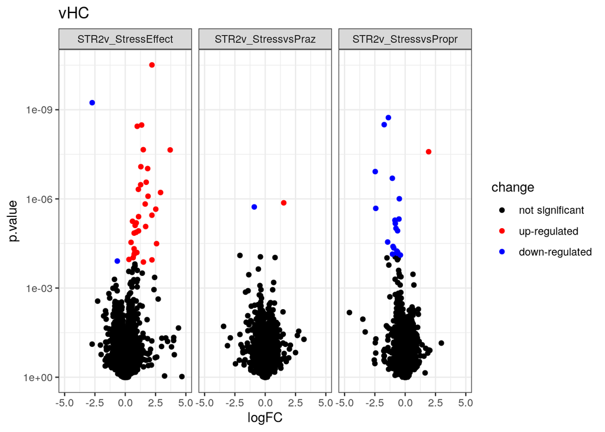

```r
VolcanovHC_S <- VolcanoPlotsEdgeR(Results[c("STR2v_StressEffect","STR2v_StressvsPraz","STR2v_StressvsPropr")],main = "vHC",limits = c(-5,5))
```

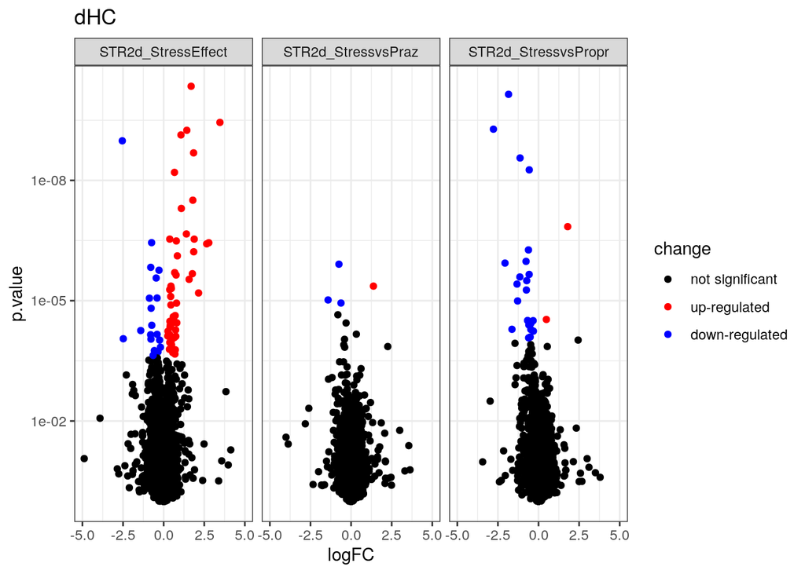

```r
VolcanodHC_S <- VolcanoPlotsEdgeR(Results[c("STR2d_StressEffect","STR2d_StressvsPraz","STR2d_StressvsPropr")], main = "dHC",limits = c(-5,5))
```

```r
FigS1A <- plot_grid(VolcanovHC_S,VolcanodHC_S,ncol = 1)
```

### Yohimbine effects (for Figure 2: Fig2X1 & Fig2X2)

New figures for Yohimbine vs Swim / Ctrl. These will no go to figure 2 and/or S2

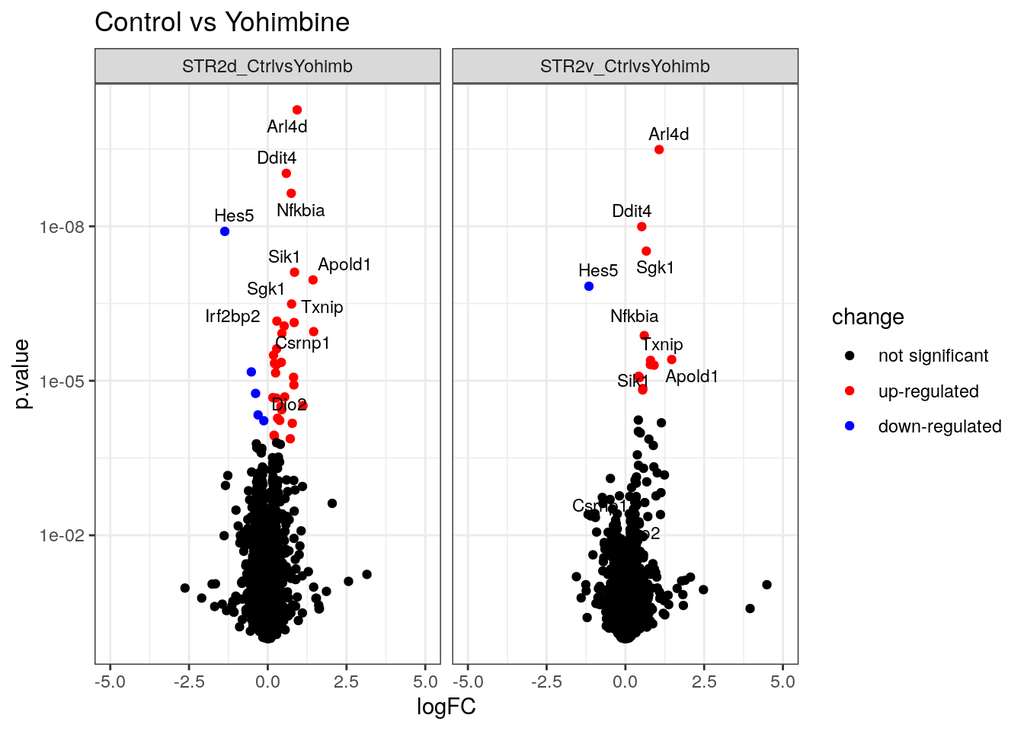

```r
Fig2X1 <- VolcanoPlotsEdgeR(Results[c("STR2d_CtrlvsYohimb","STR2v_CtrlvsYohimb")],main = "Control vs Yohimbine",limits = c(-5,5),lab = c(rownames(topTags(Results[["STR2d_CtrlvsYohimb"]])), "Dio2"))
```

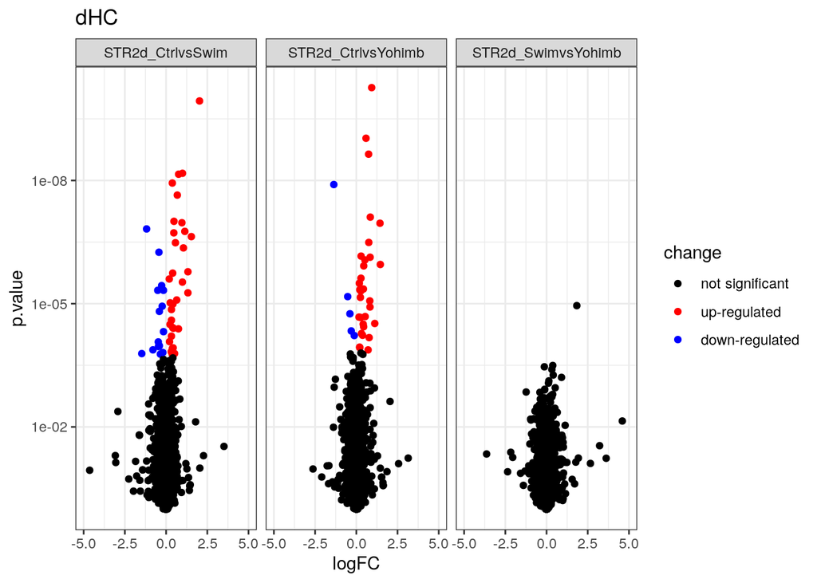

```r
VolcanovHC_CvY_d <- VolcanoPlotsEdgeR(Results[c("STR2d_CtrlvsSwim","STR2d_CtrlvsYohimb", "STR2d_SwimvsYohimb")],main = "dHC",limits = c(-5,5))
```

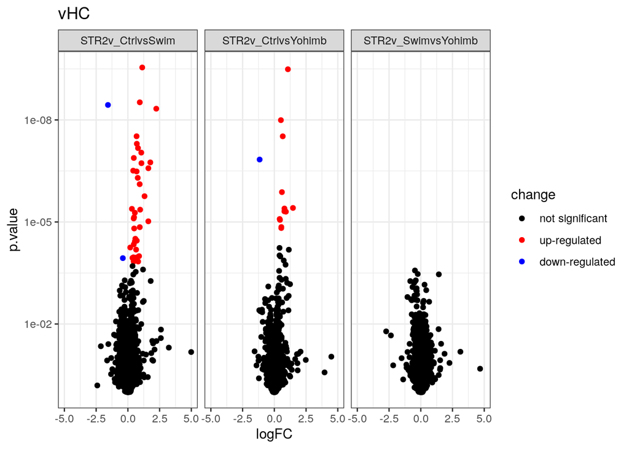

```r
VolcanovHC_CvY_v <- VolcanoPlotsEdgeR(Results[c("STR2v_CtrlvsSwim","STR2v_CtrlvsYohimb", "STR2v_SwimvsYohimb")],main = "vHC",limits = c(-5,5))
```

```r
Fig2X2 <- plot_grid(VolcanovHC_CvY_d,VolcanovHC_CvY_v,ncol = 1)
```

### Propranolol Responsive Genes (Heatmap Fig1D)

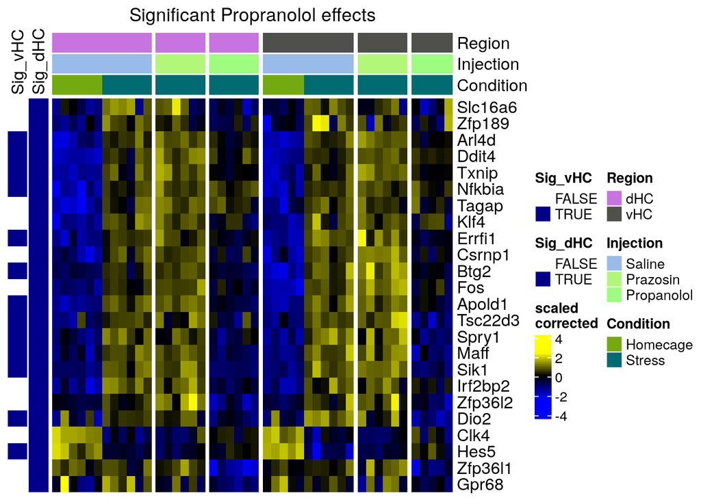

```r
#Here we produce a combined heatmap of genes with significant interaction, either in vHC or dHC
sig_int <- unique(rownames(topTags(Results[["STR2d_StressvsPropr"]],p = 0.05, n = Inf)),rownames(topTags(Results[["STR2v_StressvsPropr"]],p = 0.05, n = Inf)))
rowData(STR2p)$Sig_vHC <- FALSE
rowData(STR2p)$Sig_vHC[match(rownames(topTags(Results[["STR2v_StressvsPropr"]],p = 0.05, n = Inf)),rownames(STR2))] <- TRUE
rowData(STR2p)$Sig_dHC <- FALSE
rowData(STR2p)$Sig_dHC[match(rownames(topTags(Results[["STR2d_StressvsPropr"]],p = 0.05, n = Inf)),rownames(STR2))] <- TRUE

Fig1D <- sechm(STR2p,
     sig_int,
     gaps_at = c("Region","Injection"),
     top_annotation = c("Region","Injection","Condition"),
     left_annotation = c("Sig_vHC","Sig_dHC"),
     do.scale = T,
     cluster_rows = T,
     column_title = "Significant Propranolol effects", assay = "corrected",
     show_row_dend = FALSE)
Fig1D
```

### Propranolol response strength vHC vs dHC (Fig1E)

This figure shows the strength of the stress vs stress + propranolol in vHC vs dHC

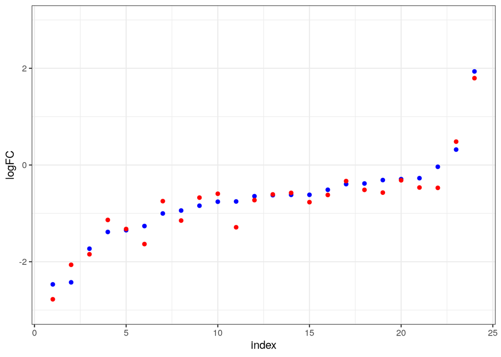

```r
vHC <- Results[["STR2v_StressvsPropr"]]$table
dHC <- Results[["STR2d_StressvsPropr"]]$table

df <- data.frame(gene = sig_int ,vHC = vHC[sig_int,"logFC"], dHC = dHC[sig_int,"logFC"])
df <- df[order(df$vHC),]
df$index <- 1:nrow(df)

Fig1E <- ggplot() + geom_point(data = df,aes(index, vHC), color = "blue") + geom_point(data = df,aes(index, dHC), color = "red") + scale_y_continuous(limits = c(-3,3)) + theme_bw() + ylab("logFC")
Fig1E
```

### Ctrl-swim vs ctrl-swim+praz strength (FigS1B)

This Figure shows the strength of the stress effect vs the stress + prazosin effect (combined hemispheres)

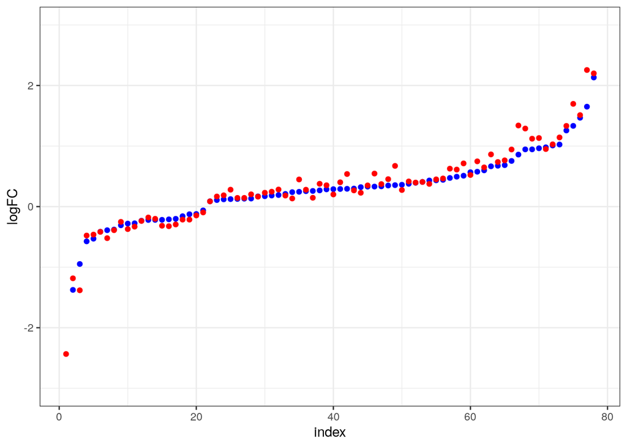

```r
vHC_sw <- Results[["STR2v_CtrlvsSwim"]]$table
dHC_sw <- Results[["STR2d_CtrlvsSwim"]]$table
vHC_swpra <- Results[["STR2v_CtrlvsPraz"]]$table
dHC_swpra <- Results[["STR2d_CtrlvsPraz"]]$table

#select genes that are expressed in all comparisons
temp <- intersect(intersect(rownames(vHC_sw),rownames(dHC_sw)),intersect(rownames(vHC_swpra),rownames(dHC_swpra)))

sw <- vHC_sw[temp,]
sw$logFC <- (sw$logFC + dHC_sw[temp,"logFC"]) / 2

sw_pra <- vHC_swpra[temp,]
sw_pra$logFC <- (sw_pra$logFC + dHC_swpra[temp,"logFC"]) / 2

df_swvswpra <- data.frame(sw = sw$logFC,sw_pra = sw_pra$logFC)
rownames(df_swvswpra) <- rownames(sw_pra)
df_swvswpra <- na.omit(df_swvswpra[sig_str,])
df_swvswpra <- df_swvswpra[order(df_swvswpra$sw),]
df_swvswpra$index <- 1:nrow(df_swvswpra)

FigS1B <- ggplot() + geom_point(data = df_swvswpra,aes(index, sw), color = "blue") + geom_point(data = df_swvswpra,aes(index, sw_pra), color = "red") + theme_bw() + ylab("logFC") + scale_y_continuous(limits = c(-3,3))
FigS1B
```

### Ctrl-swim vs ctrl-swim+prop strength (FigS1C)

This Figure shows the stength of the stress effect vs the stress + propranolol effect (combined hemispheres)

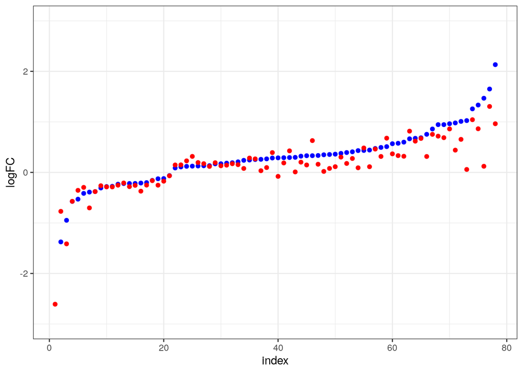

```r
vHC_sw <- Results[["STR2v_CtrlvsSwim"]]$table
dHC_sw <- Results[["STR2d_CtrlvsSwim"]]$table
vHC_swpro <- Results[["STR2v_CtrlvsPropr"]]$table
dHC_swpro <- Results[["STR2d_CtrlvsPropr"]]$table

#select genes that are expressed in all comparisons
temp <- intersect(intersect(rownames(vHC_sw),rownames(dHC_sw)),intersect(rownames(vHC_swpro),rownames(dHC_swpro)))

sw <- vHC_sw[temp,]
sw$logFC <- (sw$logFC + dHC_sw[temp,"logFC"]) / 2

sw_pro <- vHC_swpro[temp,]
sw_pro$logFC <- (sw_pro$logFC + dHC_swpro[temp,"logFC"]) / 2

df_swvswpro <- data.frame(sw = sw$logFC,sw_pro = sw_pro$logFC)
rownames(df_swvswpro) <- rownames(sw_pro)
df_swvswpro <- na.omit(df_swvswpro[sig_str,])
df_swvswpro <- df_swvswpro[order(df_swvswpro$sw),]
df_swvswpro$index <- 1:nrow(df_swvswpro)

FigS1C <- ggplot() + geom_point(data = df_swvswpro,aes(index, sw), color = "blue") + geom_point(data = df_swvswpro,aes(index, sw_pro), color = "red") + theme_bw() + ylab("logFC") + scale_y_continuous(limits = c(-3,3))
FigS1C
```

### Ctrl-swim vs ctrl- yohimbine strength (FigS1D, will now go to Figure 2!)

This Figure shows the strength of the stress effect vs the yohimbine effect (combined hemispheres)

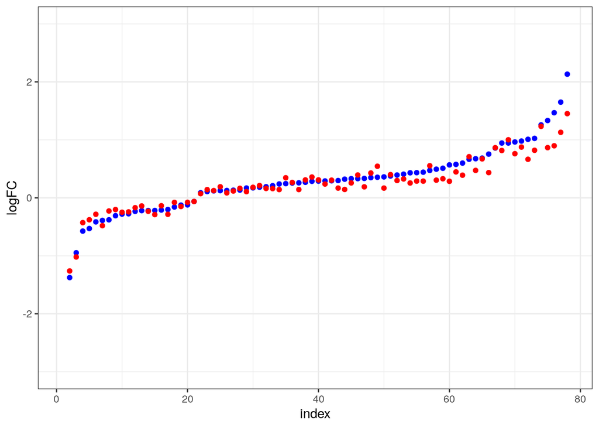

```r
vHC_sw <- Results[["STR2v_CtrlvsSwim"]]$table
dHC_sw <- Results[["STR2d_CtrlvsSwim"]]$table
vHC_yoh <- Results[["STR2v_CtrlvsYohimb"]]$table
dHC_yoh <- Results[["STR2d_CtrlvsYohimb"]]$table

#select genes that are expressed in all comparisons
temp <- intersect(intersect(rownames(vHC_sw),rownames(dHC_sw)),intersect(rownames(vHC_yoh),rownames(dHC_yoh)))

sw <- vHC_sw[temp,]
sw$logFC <- (sw$logFC + dHC_sw[temp,"logFC"]) / 2

yoh <- vHC_yoh[temp,]
yoh$logFC <- (yoh$logFC + dHC_yoh[temp,"logFC"]) / 2

df_swvsyoh <- data.frame(sw = sw$logFC,yoh = yoh$logFC)
rownames(df_swvsyoh) <- rownames(yoh)
df_swvsyoh <- na.omit(df_swvsyoh[sig_str,])
df_swvsyoh <- df_swvsyoh[order(df_swvsyoh$sw),]
df_swvsyoh$index <- 1:nrow(df_swvsyoh)

FigS1D <- ggplot() + geom_point(data = df_swvsyoh,aes(index, sw), color = "blue") + geom_point(data = df_swvsyoh,aes(index, yoh), color = "red") + theme_bw() + ylab("logFC") + scale_y_continuous(limits = c(-3,3))
FigS1D
```

### Proper design Experiment (STR3) Heatmap (Fig1F)

```r
STR3 <- dosvacor(STR3, form = ~Condition * Injection)
```

```
## Number of significant surrogate variables is:  3
## Iteration (out of 5 ):1  2  3  4  5
```

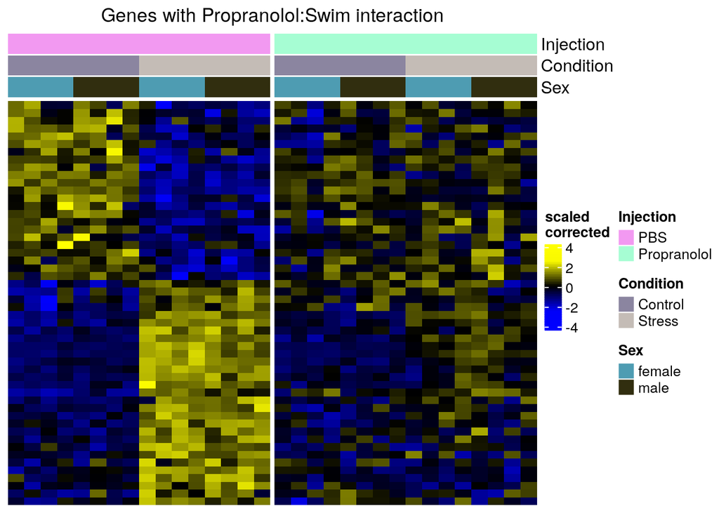

```r
STR3_design <- model.matrix(~STR3$Condition * STR3$Injection + STR3$SV1 + STR3$SV2 + STR3$SV3)

y <- DGEList(counts=assays(STR3)$counts)
y <- calcNormFactors(y)
y <- estimateDisp(y,STR3_design)
#filter out genes that are low expressed
y <- y[filterByExpr(y, STR3_design, min.count = mincount),]
STR3_fit <- glmQLFit(y,STR3_design)

Results[["STR3_FullModel"]] <- glmQLFTest(STR3_fit, colnames(STR3_design)[c(2:4,8,9)])
Results[["STR3_SwimEffect"]] <- glmQLFTest(STR3_fit, colnames(STR3_design)[2])
Results[["STR3_InteractionPropranolol"]] <- glmQLFTest(STR3_fit, colnames(STR3_design)[8])
Results[["STR3_InteractionPropranolol_stagewise"]] <- glmQLFTest(STR3_fit[rownames(topTags(Results[["STR3_SwimEffect"]], p = 0.05, n = Inf)),], colnames(STR3_design)[8])

sig_str3 <- rownames(topTags(Results[["STR3_FullModel"]],p = 0.05, n = Inf))
sig_str3_str <- rownames(topTags(Results[["STR3_SwimEffect"]],p = 0.05, n = Inf))

#Sig propranolol interaction
prop <- rownames(topTags(Results[["STR3_InteractionPropranolol_stagewise"]], n = Inf, p = 0.05))

STR3p <- STR3[,STR3$Injection != "Sotalol"]

Fig1F <- sechm(STR3p,
     prop,
     gaps_at = "Injection",
     top_annotation = c("Injection","Condition","Sex"),
     do.scale = T,
     cluster_rows = T,
     column_title = "Genes with Propranolol:Swim interaction", assay = "corrected",
     show_row_dend = FALSE)
Fig1F
```

### Propranolol Genes of STR2 in STR2+STR3 (Figure S1E)

Heatmap that shows the significant propranolol genes of STR2 in combined data of STR2 and STR3

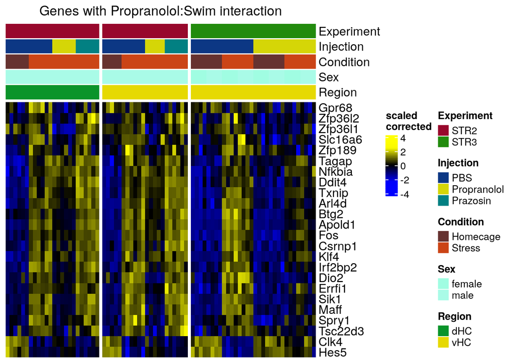

```r
STR$Injection[STR$Injection == "Propanolol"] <- "Propranolol"
STR$Injection[STR$Injection == "Saline"] <- "PBS"
STR$Injection <- factor(STR$Injection, levels = c("PBS","Yohimbine","Propranolol","Prazosin","Sotalol"))
STR$Injection[STR$Condition2 == "Saline-Yohimbine"] <- "Yohimbine"
STR$Sex[STR$Sex == "Male"] <- "male"
STR <- STR[,order(STR$Experiment, STR$Region, STR$Injection, STR$Condition, STR$Sex)]
STRp <- STR[,(STR$Injection != "Sotalol" & STR$Injection != "Yohimbine")]
FigS1E <- sechm(STRp,
     sig_int,
     gaps_at = c("Experiment","Region"),
     top_annotation = c("Experiment","Injection","Condition","Sex","Region"),
     do.scale = T,
     cluster_rows = T,
     column_title = "Genes with Propranolol:Swim interaction", assay = "corrected",
     show_row_dend = FALSE)
FigS1E
```

### Combined Analysis of STR2 and STR3 (Figure Fig1G)

Combine datasets STR2 and STR3 (only Control vs Swim / Saline vs Propranolol and only vHC) and run a sva correction prior to multiplicative model analysis for swim, propranolol and interaction effects testing. We then test for stress responsive genes that also have a significant Propranolol * Stress interaction

```r
STRprop <- STRp[,STRp$Injection != "Prazosin"]
STRprop <- STRprop[,STRprop$Region == "vHC"]
STRprop$Injection <- droplevels(STRprop$Injection)
STRprop$Condition <- droplevels(STRprop$Condition)

STRprop <- dosvacor(STRprop, form = ~Condition * Injection + Experiment, form0 = ~Experiment)
```

```
## Number of significant surrogate variables is:  5
## Iteration (out of 5 ):1  2  3  4  5
```

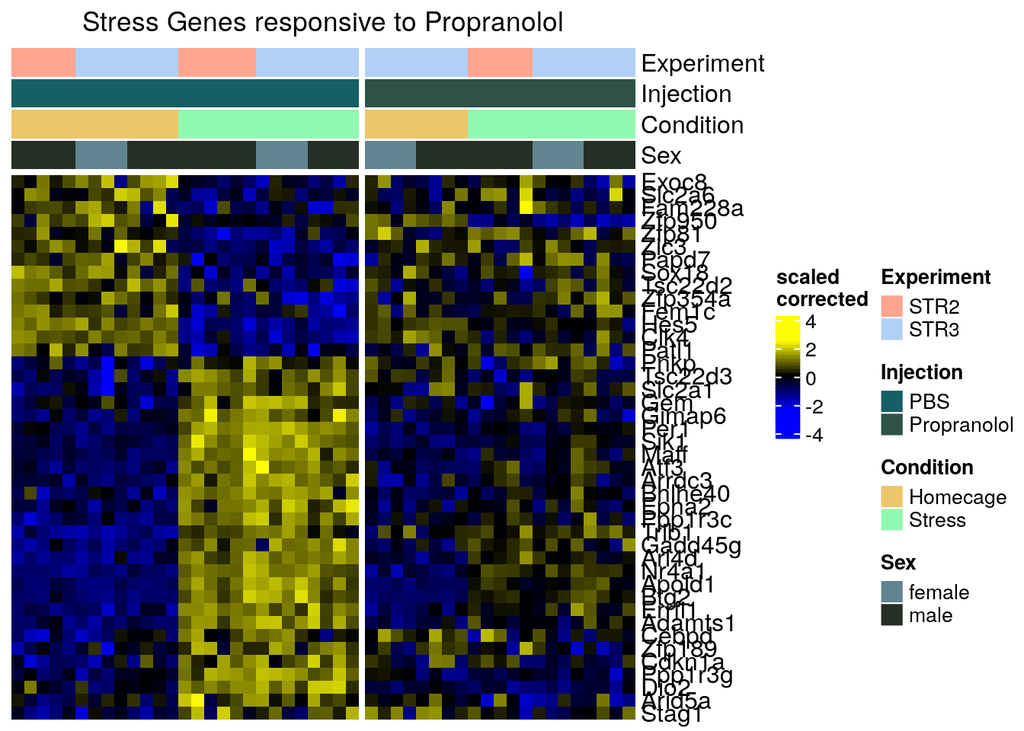

```r
STRprop_design <- model.matrix(~STRprop$Condition * STRprop$Injection + STRprop$SV1 + STRprop$SV2 + STRprop$SV3 + STRprop$SV4 + STRprop$SV5)

y <- DGEList(counts=assays(STRprop)$counts)
y <- calcNormFactors(y)
y <- estimateDisp(y,STRprop_design)
#filter out genes that are low expressed
y <- y[filterByExpr(y, STRprop_design, min.count = mincount),]
STRprop_fit <- glmQLFit(y,STRprop_design)

Results[["STRprop_FullModel"]] <- glmQLFTest(STRprop_fit, colnames(STRprop_design)[c(2,3,9)])
Results[["STRprop_Stress"]] <- glmQLFTest(STRprop_fit, colnames(STRprop_design)[2])
Results[["STRprop_Propranolol"]] <- glmQLFTest(STRprop_fit, colnames(STRprop_design)[3])
Results[["STRprop_Interaction"]] <- glmQLFTest(STRprop_fit, colnames(STRprop_design)[9])

#to further boost significance we use a stagewise multiple testing method, where we only check stress responsive genes for a significant interaction term
Results[["STRprop_Interaction_stagewise"]] <- glmQLFTest(STRprop_fit[rownames(topTags(Results[["STRprop_Stress"]], p = 0.05, n = Inf)),], colnames(STRprop_design)[9])

STRprop <- STRprop[,order(STRprop$Injection,STRprop$Condition)]

Fig1G <- sechm(STRprop,
     rownames(topTags(Results[["STRprop_Interaction_stagewise"]], n = Inf, p = 0.05)),
     top_annotation = c("Experiment","Injection","Condition","Sex"),
     gaps_at = c("Injection"),
     do.scale = T,
     cluster_rows = T,
     column_title = "Stress Genes responsive to Propranolol", assay = "corrected",
     show_row_dend = FALSE)
Fig1G
```

### Expression of Dio2 and other genes (Figure S1F_gene)

multiple figures that show the expression of Dio2 and other genes across all datasets (without Sotalol or Yohimbine)

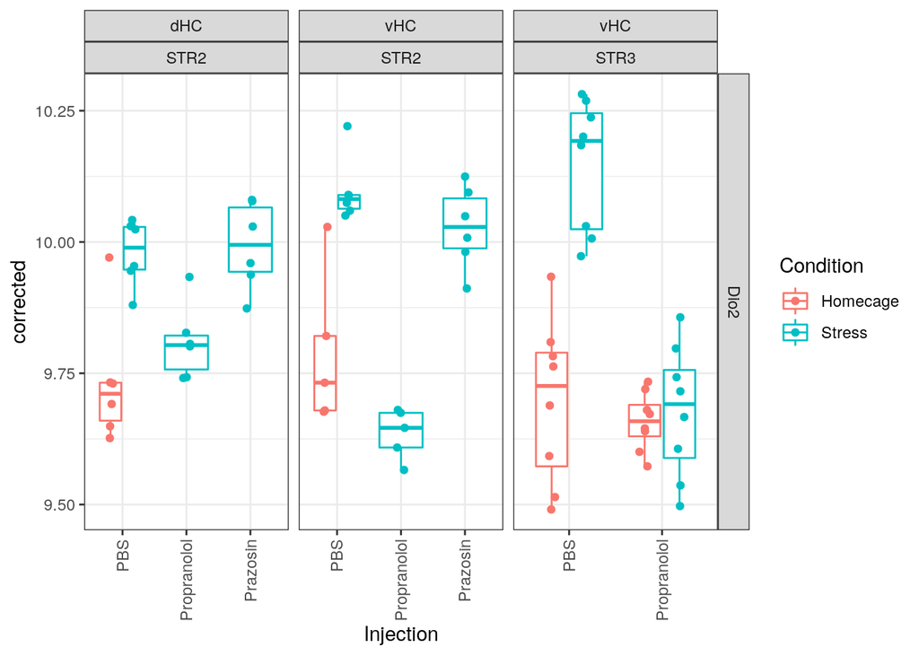

```r
plotdat <- meltSE(STR,c("Dio2"))
plotdat <- plotdat[!(plotdat$Injection %in% c("Yohimbine","Sotalol")),]

FigS1F_Dio2 <- ggplot(plotdat, aes(Injection, corrected, color = Condition)) +
  geom_boxplot(outlier.shape = NA) +
  geom_point(position = position_jitterdodge()) +
  facet_grid(feature~Region +Experiment, scales = "free") +
  theme_bw() +
  theme(axis.text.x = element_text(angle = 90, vjust = 0.5, hjust=1))
FigS1F_Dio2
```

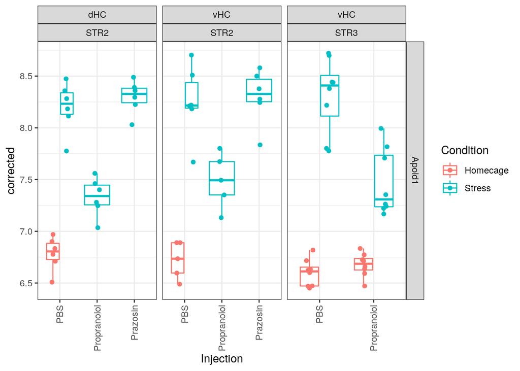

```r
plotdat <- meltSE(STR,c("Apold1"))
plotdat <- plotdat[!(plotdat$Injection %in% c("Yohimbine","Sotalol")),]

FigS1F_Apold1 <- ggplot(plotdat, aes(Injection, corrected, color = Condition)) +
  geom_boxplot(outlier.shape = NA) +
  geom_point(position = position_jitterdodge()) +
  facet_grid(feature~Region +Experiment, scales = "free") +
  theme_bw() +
  theme(axis.text.x = element_text(angle = 90, vjust = 0.5, hjust=1))
FigS1F_Apold1
```

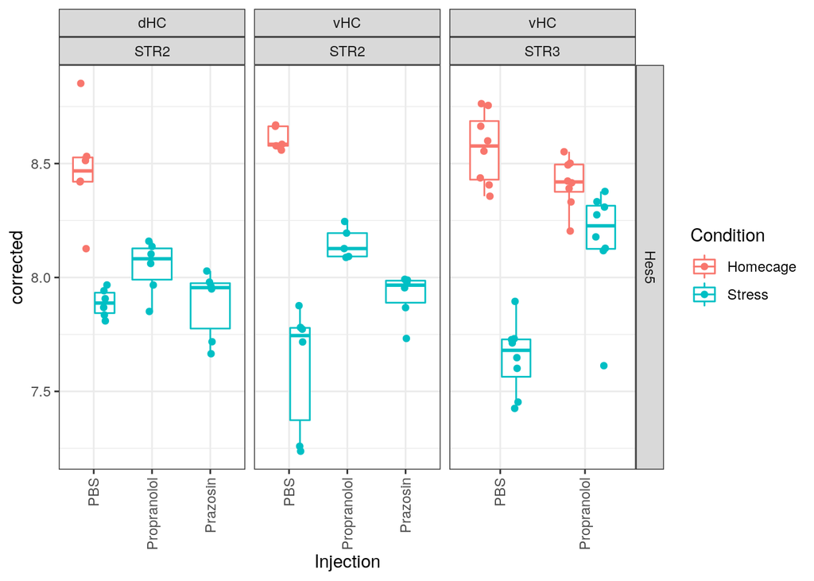

```r
plotdat <- meltSE(STR,c("Hes5"))
plotdat <- plotdat[!(plotdat$Injection %in% c("Yohimbine","Sotalol")),]

FigS1F_Hes5 <- ggplot(plotdat, aes(Injection, corrected, color = Condition)) +
  geom_boxplot(outlier.shape = NA) +
  geom_point(position = position_jitterdodge()) +
  facet_grid(feature~Region +Experiment, scales = "free") +
  theme_bw() +
  theme(axis.text.x = element_text(angle = 90, vjust = 0.5, hjust=1))
FigS1F_Hes5
```

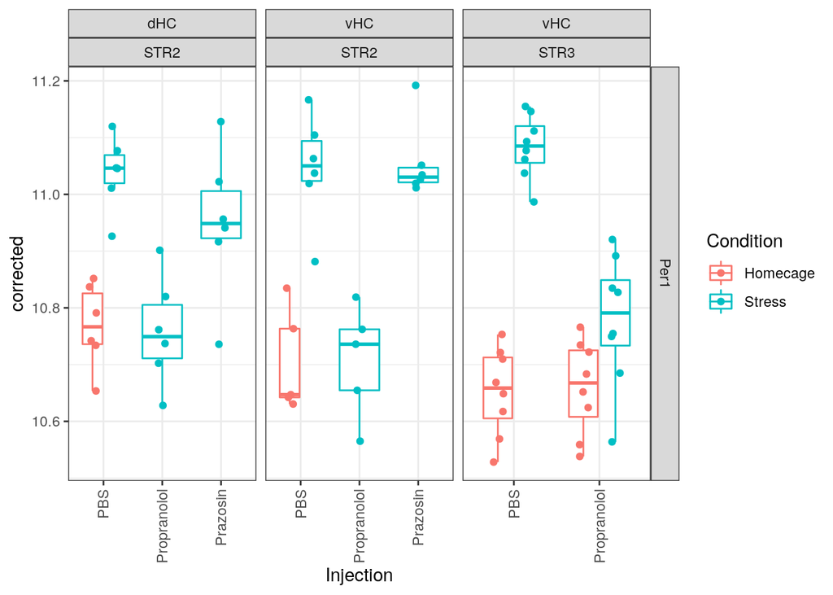

```r
plotdat <- meltSE(STR,c("Per1"))
plotdat <- plotdat[!(plotdat$Injection %in% c("Yohimbine","Sotalol")),]

FigS1F_Per1 <- ggplot(plotdat, aes(Injection, corrected, color = Condition)) +
  geom_boxplot(outlier.shape = NA) +
  geom_point(position = position_jitterdodge()) +
  facet_grid(feature~Region +Experiment, scales = "free") +
  theme_bw() +
  theme(axis.text.x = element_text(angle = 90, vjust = 0.5, hjust=1))
FigS1F_Per1
```

## Show Final Figures

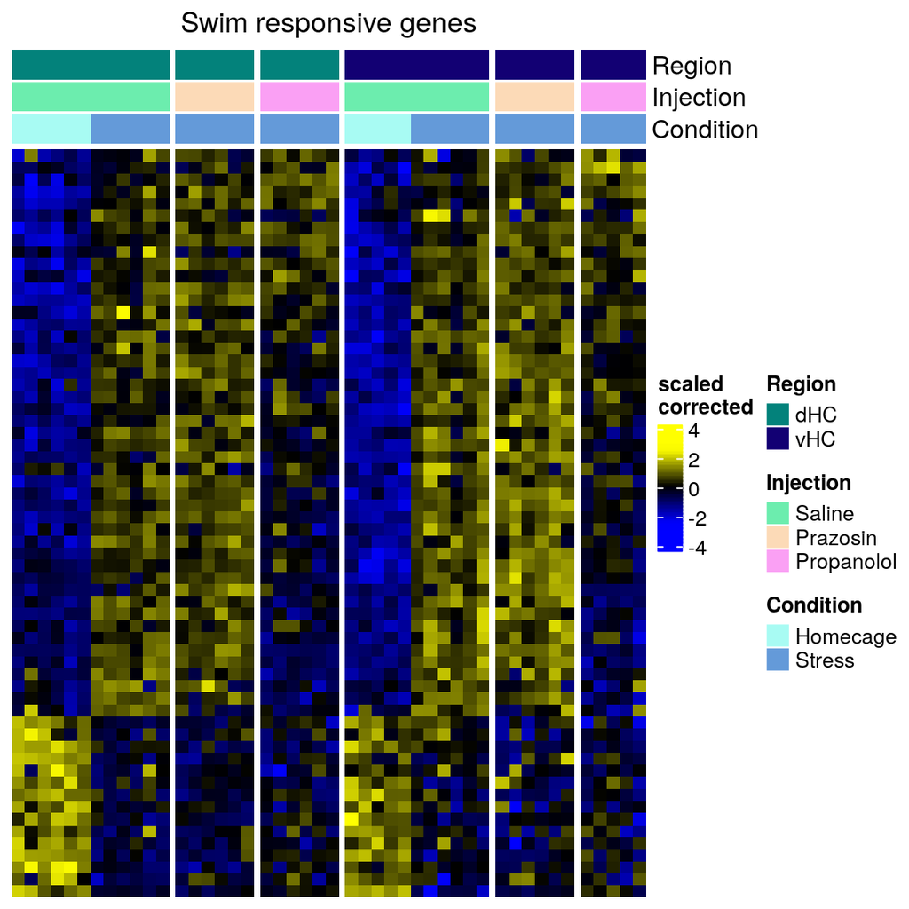

```r
print(Fig1B)
```

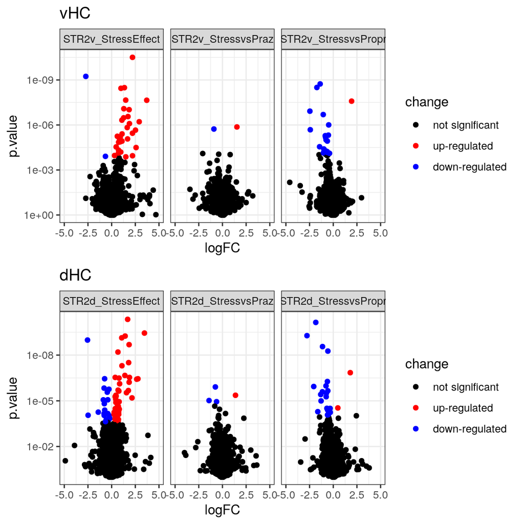

```r
print(FigS1A)
```

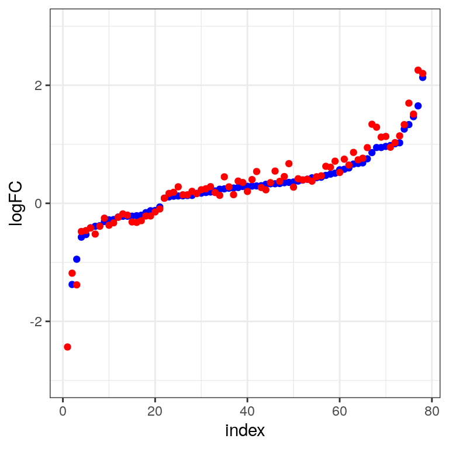

```r
print(FigS1B)
```

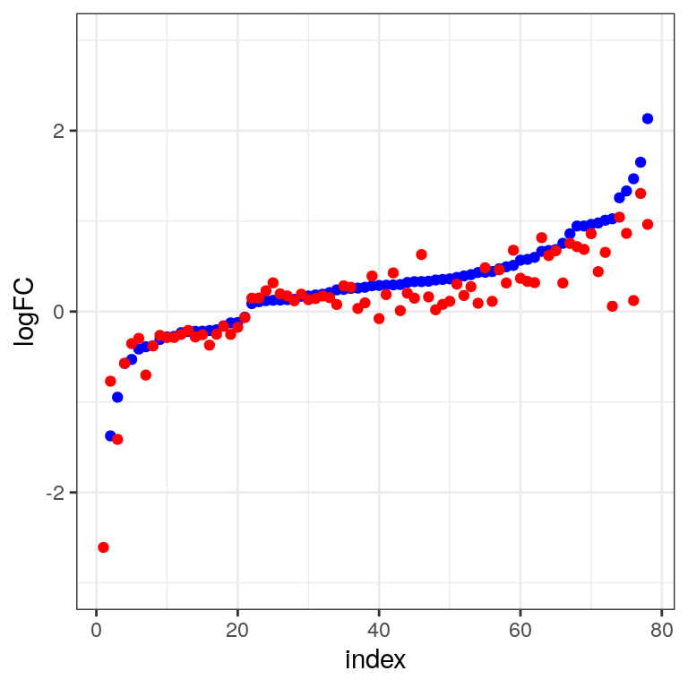

```r
print(FigS1C)
```

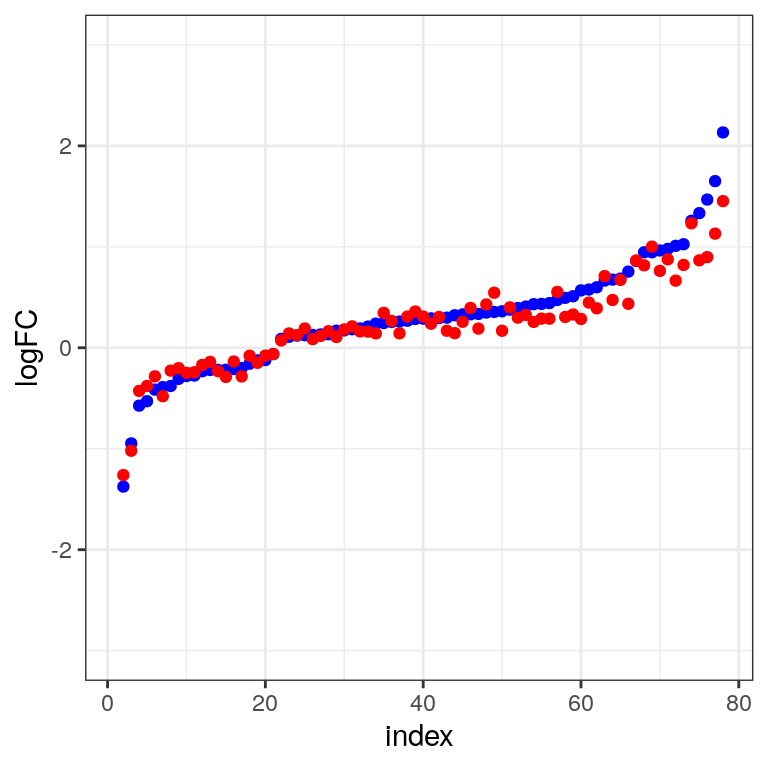

```r
print(FigS1D)
```

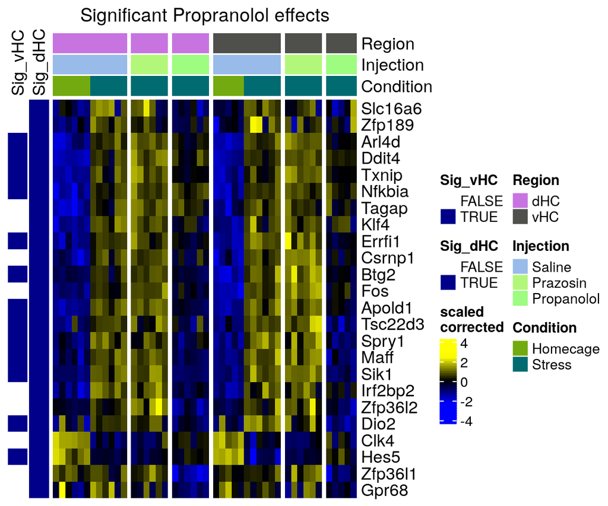

```r
print(Fig1D)
```

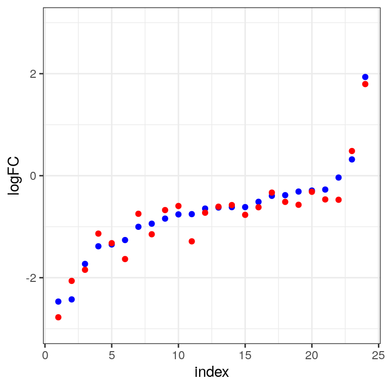

```r
print(Fig1E)
```

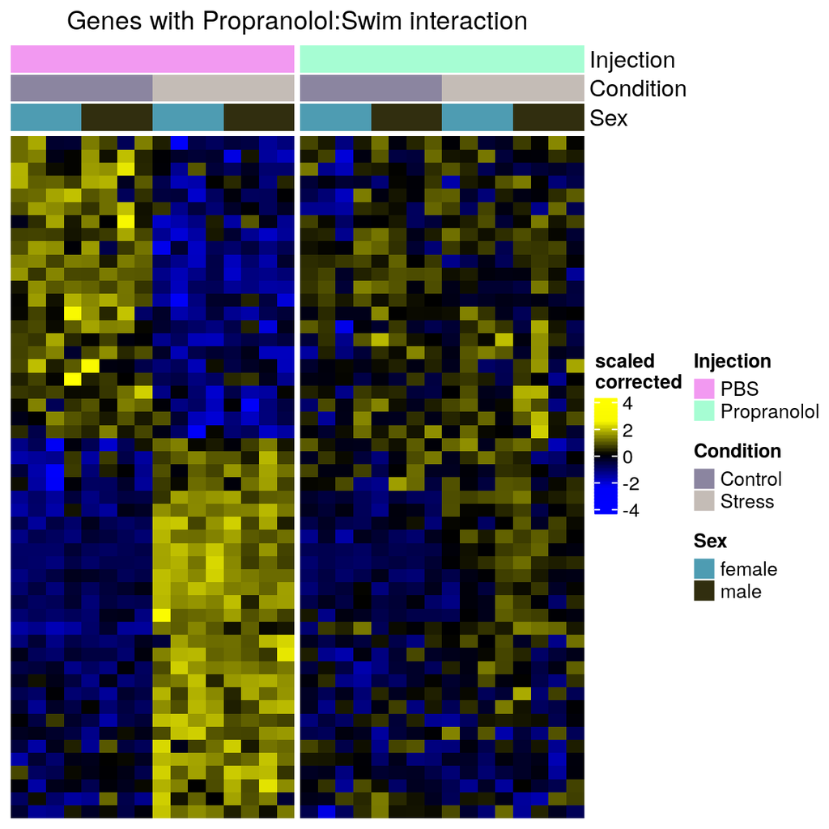

```r
print(Fig1F)
```

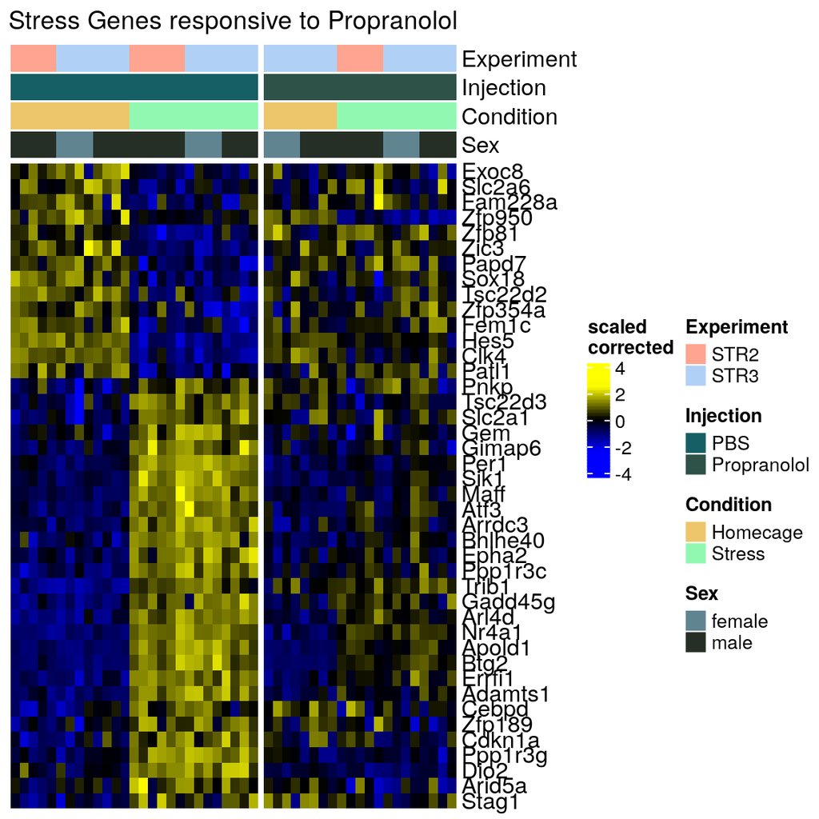

```r
print(Fig1G)
```

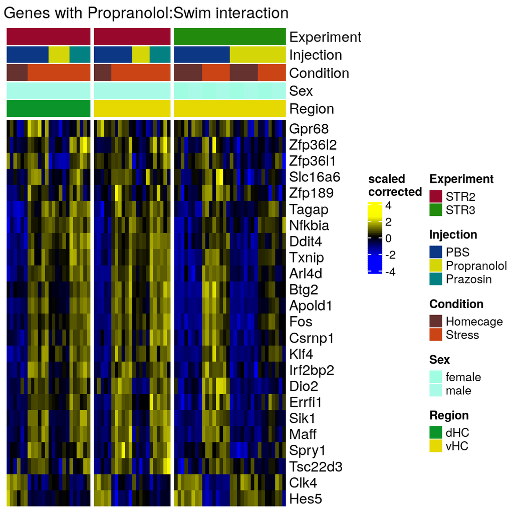

```r
print(FigS1E)
```

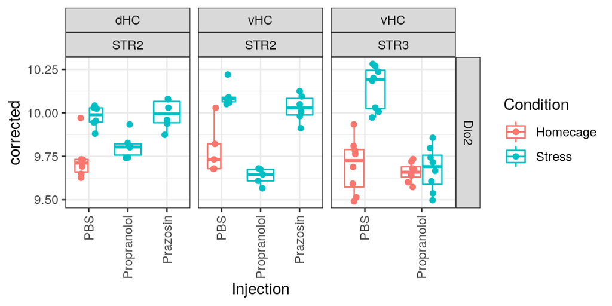

```r
print(FigS1F_Dio2)
```

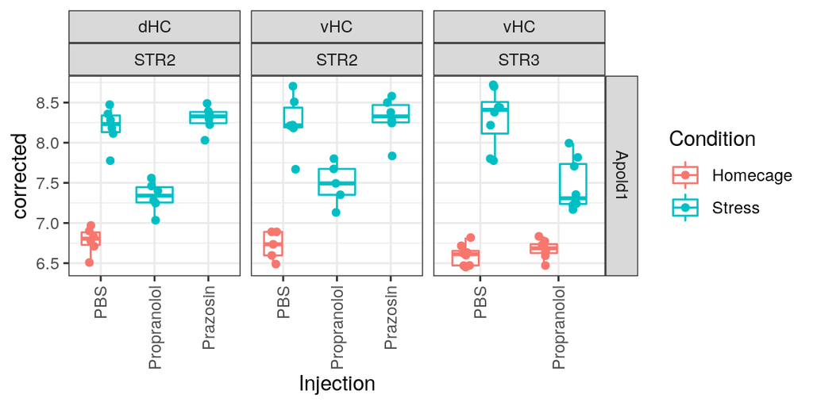

```r
print(FigS1F_Apold1)
```